# 6. ARIMA Modeling

# (6-1) MODEL NON-STATINARY TS

[Nao Mimoto](https://nmimoto.github.io/) - [Dept. of Statistics](http://www.uakron.edu/stat/) : [The University of Akron](http://www.uakron.edu)

[TS Class Web Page](https://nmimoto.github.io/477/) – [R resource page](https://nmimoto.github.io/R/)

# 1. Non-stationary time series

## Daily Price of Dow Jones

- From Aug. 28 to Dec. 18, 1972 (Brockwell p.153)

See Shumway p145 GNP modeling with ARIMA

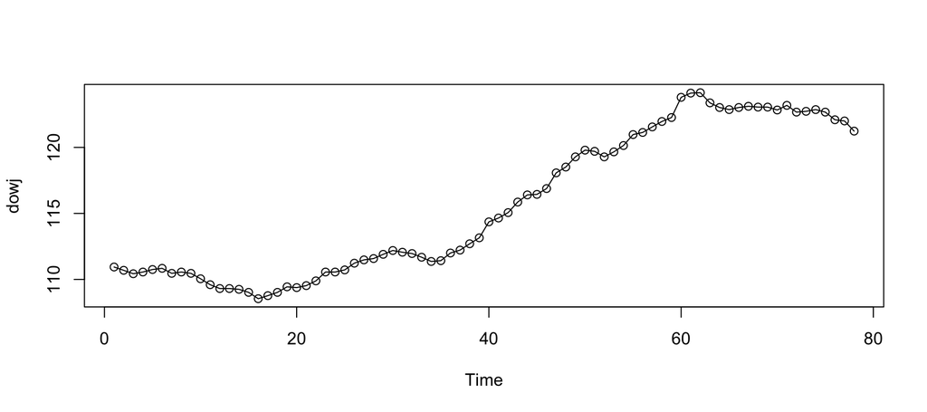

```r
  D <- read.csv("https://nmimoto.github.io/datasets/dowj.csv", header=TRUE)
  Dowj  <- ts(D, start=1, freq=1)    # turn D into TS object
  plot(Dowj, type="o")               # plot with both line and circle
```

- Stationary?

## Lake Huron Data

- Annual Level of Lake Huron 1875-1972

[figure not shown]

```r
  D <- read.csv("http://gozips.uakron.edu/~nmimoto/pages/datasets/lake.csv", header=TRUE)
  Lake  <- ts(D, start=1875,, freq=1)  # turn it into TS object startng year 1875
  plot(Lake, type="o")
```

- Stationary?

## Global Temperature Data

Global mean land-ocean temparature data from Shumway p.4

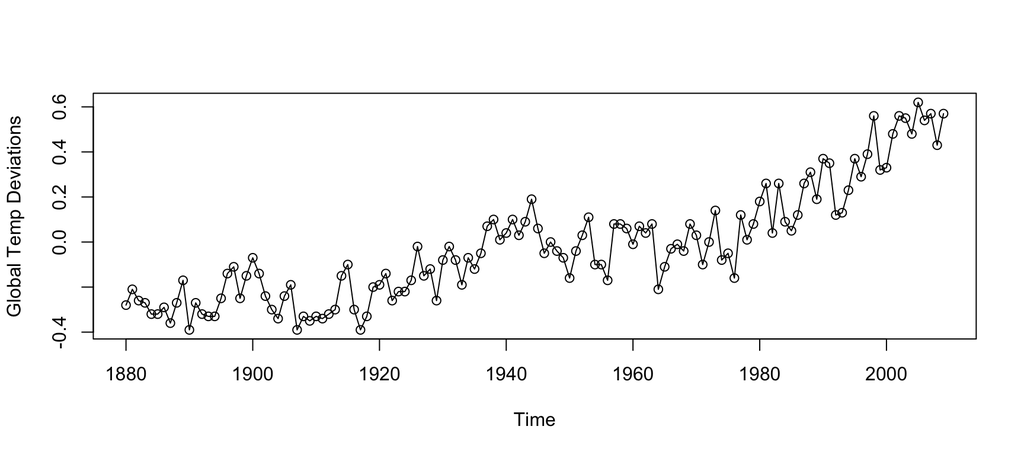

```r
  library(astsa)     # do install.packages("astsa") if not installed yet
  data(gtemp)        # load data that is inside astsa package
  plot(gtemp, type="o", ylab="Global Temp Deviations")
```

- Stationary?

# 2. Tests for Stationarity

How do you check if a time seirs is stationary?

- Visual inspection for constant mean, constant variance
- KPSS test ($H_0$: Stationary)
- ADF test ($H_0$: Not Stationary)
- PP test ($H_0$: Not Stationary)
- Fit AR(1), and see if $\hat \phi_1$ is significantly different from 1.

## KPSS test

Kwiatkowski-Phillips-Schmidt-Shin (1992) test for

- Default choice in **auto.arima()**
  $$\left\{
  \begin{array}{ll}
  H_0: X_t \mbox{ is trend stationary}\\
  H_A: X_t \mbox{ is not stationary} \\
  \end{array} \right.$$
- Large p-value means “Stationary”.
- Decompose the series as
  $$X_t \hspace{3mm} = \hspace{3mm} T_t + W_t + Y_t$$
  where $T_t$ is deterministic trend, $W_t$ is random walk, and $Y_t$ is stationary error.
- Lagrange multiplier test that the random walk has zero variance.

## ADF test

Augumented Dickey-Fuller test (Brockwell p. 194)

- “Unit-root” test
- The stationarity hypothesis
  $$\left\{
  \begin{array}{ll}
  H_0: Y_t \mbox{ is not stationary} \\
  H_A: Y_t \mbox{ is stationary}
  \end{array} \right.$$
- Is replaced by
  $$\left\{
  \begin{array}{ll}
  H_0: Y_t \mbox{ has unit root} \\
  H_A: Y_t \mbox{ does not have unit root }
  \end{array} \right.$$
- Small p-value rejects the null hypothesis of non-stationarity, and means “Stationary”.
- Fit AR(1) to a time series, and test if $\phi_1$ is significantly different from 1, by
  $$\frac{ \hat \phi_1 -1 }{ SE(\hat \phi_1) } \sim N(0,1)$$

## PP test

Phillips-Perron test for the null hypothesis that x has a unit root.

- Same Hypothesis as ADF test
- Small p-value means “Stationary”.
- The tests are similar to ADF tests, but they incorporate an automatic correction to the DF procedure to all ow for autocorrelated residuals.
- Calculation of the test statistics is complex.
- The tests usually give the same conclusions as the ADF tests

**P-value of (KPSS, ADF, PP) tests**

[output not shown]

- **Stationarity.tests()** performs all of the three tests.

```r
 #- same file as Randomness.tests()
 source("https://nmimoto.github.io/477/TS_R-90.txt")
                         # load Stationarity.tests() from class web page.
```

## Ex: Use it on above datasets

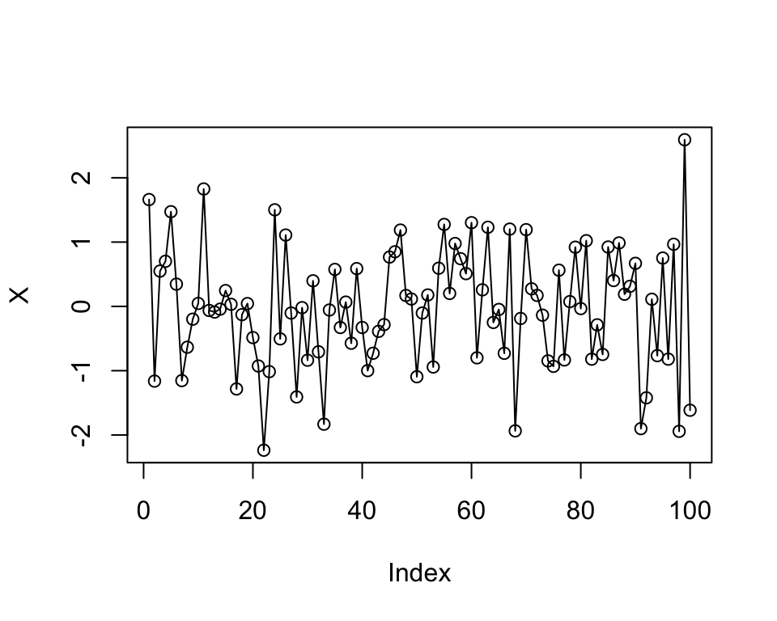

```r
  source("https://nmimoto.github.io/477/TS_R-90.txt")
                          # Load Stationarity.tests() from Course Webpage

  #--- Test it on random sample ---
  X <- rnorm(100)
  plot(X, type="o")
```

```r
  Stationarity.tests(X)
```

```
##        KPSS  ADF   PP
## p-val:  0.1 0.01 0.01
```

- Large, small, small $\to$ stationary. As it should be.

[figure not shown]

```r
  #--- Lake Huron Data ---
  plot(Lake, type="o")
```

```r
  Stationarity.tests(Lake)
```

```
##        KPSS  ADF   PP
## p-val:  0.1 0.01 0.01
```

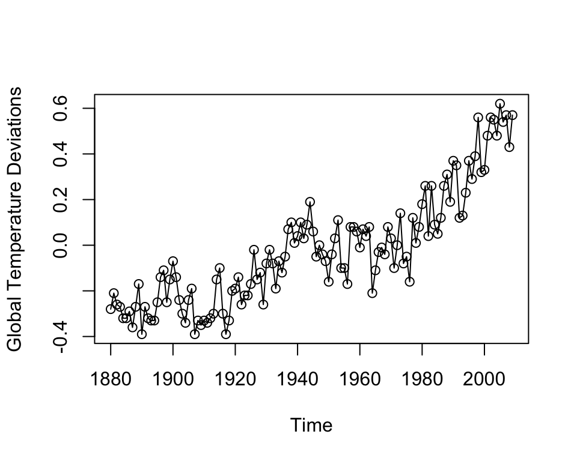

```r
  #--- Global Temp Data ---
  plot(gtemp, type="o", ylab="Global Temperature Deviations")
```

```r
  Stationarity.tests(gtemp)
```

```
##        KPSS   ADF   PP
## p-val: 0.01 0.706 0.01
```